# Project: Customer Segmentation for Arvato Financial Services

In this project, I will apply unsupervised learning techniques to identify a certain set of customer within a market that form the core customer base for a mail-order sales company in Germany. When creating customer segmentation, the segments can then be used to direct marketing campaigns towards audiences that will have the highest expected rate of returns and one can know which part of the general population are more likely to be a customer and which part are not. The data that I will use has been provided by Udacity partners at Bertelsmann Arvato Analytics, and represents a real-life data science task. The Data has some restrictions of use from the company, so I decided to work on the Udacity workspace where the data is provided and ready to use.

```python
# import libraries here; add more as necessary
import numpy as np
import pandas as pd
import matplotlib.pyplot as plt
import seaborn as sns
from sklearn.preprocessing import StandardScaler, Imputer
from sklearn.decomposition import PCA
from sklearn.cluster import KMeans


# magic word for producing visualizations in notebook
%matplotlib inline
```

### Load the Data

```python
# Load in the general demographics data.
azdias = pd.read_csv('../../data/Term2/capstone/arvato_data/Udacity_AZDIAS_052018.csv', sep=';')

# Load in the feature summary file.
feat_info =  pd.read_table('AZDIAS_Feature_Summary.csv', sep= ';')
```

```python
# Check the structure of the data after it's loaded (e.g. print the number of
# rows and columns, print the first few rows).
azdias.shape
```

```
(891221, 85)
```

```python
azdias.head()
```

|  | AGER_TYP | ALTERSKATEGORIE_GROB | ANREDE_KZ | CJT_GESAMTTYP | FINANZ_MINIMALIST | FINANZ_SPARER | FINANZ_VORSORGER | FINANZ_ANLEGER | FINANZ_UNAUFFAELLIGER | FINANZ_HAUSBAUER | ... | PLZ8_ANTG1 | PLZ8_ANTG2 | PLZ8_ANTG3 | PLZ8_ANTG4 | PLZ8_BAUMAX | PLZ8_HHZ | PLZ8_GBZ | ARBEIT | ORTSGR_KLS9 | RELAT_AB |
| --- | --- | --- | --- | --- | --- | --- | --- | --- | --- | --- | --- | --- | --- | --- | --- | --- | --- | --- | --- | --- | --- |
| 0 | -1 | 2 | 1 | 2.0 | 3 | 4 | 3 | 5 | 5 | 3 | ... | NaN | NaN | NaN | NaN | NaN | NaN | NaN | NaN | NaN | NaN |
| 1 | -1 | 1 | 2 | 5.0 | 1 | 5 | 2 | 5 | 4 | 5 | ... | 2.0 | 3.0 | 2.0 | 1.0 | 1.0 | 5.0 | 4.0 | 3.0 | 5.0 | 4.0 |
| 2 | -1 | 3 | 2 | 3.0 | 1 | 4 | 1 | 2 | 3 | 5 | ... | 3.0 | 3.0 | 1.0 | 0.0 | 1.0 | 4.0 | 4.0 | 3.0 | 5.0 | 2.0 |
| 3 | 2 | 4 | 2 | 2.0 | 4 | 2 | 5 | 2 | 1 | 2 | ... | 2.0 | 2.0 | 2.0 | 0.0 | 1.0 | 3.0 | 4.0 | 2.0 | 3.0 | 3.0 |
| 4 | -1 | 3 | 1 | 5.0 | 4 | 3 | 4 | 1 | 3 | 2 | ... | 2.0 | 4.0 | 2.0 | 1.0 | 2.0 | 3.0 | 3.0 | 4.0 | 6.0 | 5.0 |

5 rows × 85 columns

## Preprocessing

#### Convert Missing Value Codes to NaNs

```python
# Identify missing or unknown data values and convert them to NaNs.

azdias.isnull().sum()
```

```
AGER_TYP                      0
ALTERSKATEGORIE_GROB          0
ANREDE_KZ                     0
CJT_GESAMTTYP              4854
FINANZ_MINIMALIST             0
FINANZ_SPARER                 0
FINANZ_VORSORGER              0
FINANZ_ANLEGER                0
FINANZ_UNAUFFAELLIGER         0
FINANZ_HAUSBAUER              0
FINANZTYP                     0
GEBURTSJAHR                   0
GFK_URLAUBERTYP            4854
GREEN_AVANTGARDE              0
HEALTH_TYP                    0
LP_LEBENSPHASE_FEIN        4854
LP_LEBENSPHASE_GROB        4854
LP_FAMILIE_FEIN            4854
LP_FAMILIE_GROB            4854
LP_STATUS_FEIN             4854
LP_STATUS_GROB             4854
NATIONALITAET_KZ              0
PRAEGENDE_JUGENDJAHRE         0
RETOURTYP_BK_S             4854
SEMIO_SOZ                     0
SEMIO_FAM                     0
SEMIO_REL                     0
SEMIO_MAT                     0
SEMIO_VERT                    0
SEMIO_LUST                    0
                          ...
OST_WEST_KZ               93148
WOHNLAGE                  93148
CAMEO_DEUG_2015           98979
CAMEO_DEU_2015            98979
CAMEO_INTL_2015           98979
KBA05_ANTG1              133324
KBA05_ANTG2              133324
KBA05_ANTG3              133324
KBA05_ANTG4              133324
KBA05_BAUMAX             133324
KBA05_GBZ                133324
BALLRAUM                  93740
EWDICHTE                  93740
INNENSTADT                93740
GEBAEUDETYP_RASTER        93155
KKK                      121196
MOBI_REGIO               133324
ONLINE_AFFINITAET          4854
REGIOTYP                 121196
KBA13_ANZAHL_PKW         105800
PLZ8_ANTG1               116515
PLZ8_ANTG2               116515
PLZ8_ANTG3               116515
PLZ8_ANTG4               116515
PLZ8_BAUMAX              116515
PLZ8_HHZ                 116515
PLZ8_GBZ                 116515
ARBEIT                    97216
ORTSGR_KLS9               97216
RELAT_AB                  97216
Length: 85, dtype: int64
```

```python
azdias.isnull().sum().sum()
```

```
4896838
```

```python
feat_info.head()
```

|  | attribute | information_level | type | missing_or_unknown |
| --- | --- | --- | --- | --- |
| 0 | AGER_TYP | person | categorical | [-1,0] |
| 1 | ALTERSKATEGORIE_GROB | person | ordinal | [-1,0,9] |
| 2 | ANREDE_KZ | person | categorical | [-1,0] |
| 3 | CJT_GESAMTTYP | person | categorical | [0] |
| 4 | FINANZ_MINIMALIST | person | ordinal | [-1] |

```python
feat_info.missing_or_unknown.value_counts()
```

```
[-1]        26
[-1,9]      17
[-1,0]      16
[0]         12
[]          10
[-1,0,9]     1
[XX]         1
[-1,X]       1
[-1,XX]      1
Name: missing_or_unknown, dtype: int64
```

```python
feat_info.missing_or_unknown.loc[0]
```

```
'[-1,0]'
```

```python
#convertto missing or unknown to NaNs
for x in range(len(feat_info)):
    missing_or_unknown = feat_info.iloc[x]['missing_or_unknown']
    missing_or_unknown = missing_or_unknown.strip('[')
    missing_or_unknown = missing_or_unknown.strip(']')
    missing_or_unknown = missing_or_unknown.split(sep=',')
    missing_or_unknown = [int(value) if (value!='X' and value!='XX' and value!='') else value for value in missing_or_unknown]
    if missing_or_unknown != ['']:
        azdias = azdias.replace({feat_info.iloc[x]['attribute']: missing_or_unknown}, np.nan)
```

```python
azdias.isnull().sum().sum()
```

```
8373929
```

```python
feat_info.missing_or_unknown.loc[0]
```

```
'[-1,0]'
```

#### Drop the outlier columns (in terms of the proportion of values that are missing)

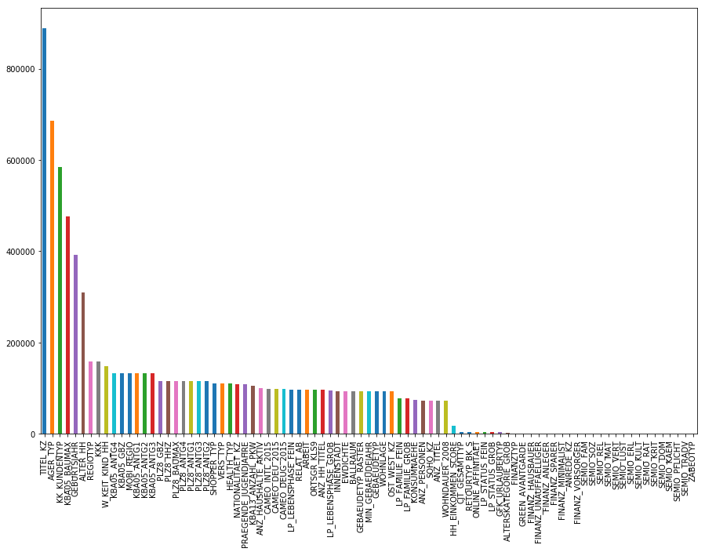

```python
# Perform an assessment of how much missing data there is in each column of the
# dataset.
# Investigate patterns in the amount of missing data in each column.

azdias.isnull().sum().sort_values(ascending=False).plot.bar(figsize=(15,10));
```

```python
#The percenatge of missing values per column.
(azdias.isnull().sum().sort_values(ascending=False)/azdias.shape[0])
```

```
TITEL_KZ                 0.997576
AGER_TYP                 0.769554
KK_KUNDENTYP             0.655967
KBA05_BAUMAX             0.534687
GEBURTSJAHR              0.440203
ALTER_HH                 0.348137
REGIOTYP                 0.177357
KKK                      0.177357
W_KEIT_KIND_HH           0.166051
KBA05_ANTG4              0.149597
KBA05_GBZ                0.149597
MOBI_REGIO               0.149597
KBA05_ANTG1              0.149597
KBA05_ANTG2              0.149597
KBA05_ANTG3              0.149597
PLZ8_GBZ                 0.130736
PLZ8_HHZ                 0.130736
PLZ8_BAUMAX              0.130736
PLZ8_ANTG4               0.130736
PLZ8_ANTG1               0.130736
PLZ8_ANTG3               0.130736
PLZ8_ANTG2               0.130736
SHOPPER_TYP              0.124768
VERS_TYP                 0.124768
HEALTH_TYP               0.124768
NATIONALITAET_KZ         0.121536
PRAEGENDE_JUGENDJAHRE    0.121366
KBA13_ANZAHL_PKW         0.118714
ANZ_HAUSHALTE_AKTIV      0.111769
CAMEO_INTL_2015          0.111479
                           ...
RETOURTYP_BK_S           0.005446
ONLINE_AFFINITAET        0.005446
LP_STATUS_FEIN           0.005446
LP_STATUS_GROB           0.005446
GFK_URLAUBERTYP          0.005446
ALTERSKATEGORIE_GROB     0.003233
FINANZTYP                0.000000
GREEN_AVANTGARDE         0.000000
FINANZ_HAUSBAUER         0.000000
FINANZ_UNAUFFAELLIGER    0.000000
FINANZ_ANLEGER           0.000000
FINANZ_SPARER            0.000000
FINANZ_MINIMALIST        0.000000
ANREDE_KZ                0.000000
FINANZ_VORSORGER         0.000000
SEMIO_FAM                0.000000
SEMIO_SOZ                0.000000
SEMIO_REL                0.000000
SEMIO_MAT                0.000000
SEMIO_VERT               0.000000
SEMIO_LUST               0.000000
SEMIO_ERL                0.000000
SEMIO_KULT               0.000000
SEMIO_RAT                0.000000
SEMIO_KRIT               0.000000
SEMIO_DOM                0.000000
SEMIO_KAEM               0.000000
SEMIO_PFLICHT            0.000000
SEMIO_TRADV              0.000000
ZABEOTYP                 0.000000
Length: 85, dtype: float64
```

```python
# drop the outlier columns from the dataset (Columns with mean > 0.3)
drop_columns = ['AGER_TYP','GEBURTSJAHR','TITEL_KZ','ALTER_HH','KK_KUNDENTYP','KBA05_BAUMAX']
azdias = azdias.drop(drop_columns, axis=1)
```

```python
# remove dropped columns from feature info
feat_info = feat_info[~feat_info['attribute'].isin(drop_columns)]
```

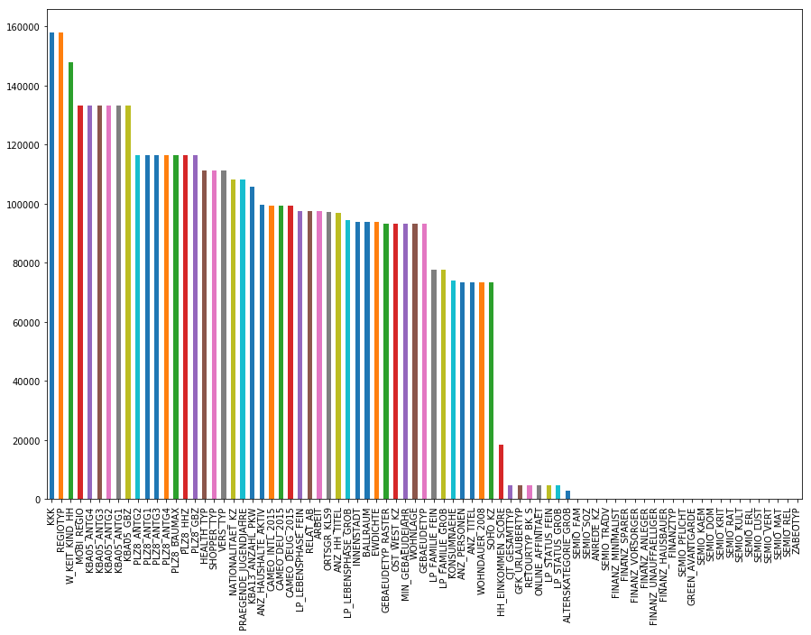

```python
# make sure columns were dropped
azdias.isnull().sum().sort_values(ascending=False).plot.bar(figsize=(15,10));
```

#### Discussion

Six columns: 'AGER_TYP','GEBURTSJAHR','TITEL_KZ','ALTER_HH','KK_KUNDENTYP','KBA05_BAUMAX'] are columns that have more than 20% missing values. Thus, these columns need to be dropped.

#### Drop rows that have more than 20 missing values per row

```python
# How much data is missing in each row of the dataset?
azdias.isnull().sum(axis=1).sort_values(ascending=False)
```

```
643174    49
732775    49
472919    48
183108    47
139316    47
691141    47
691142    47
691171    47
691183    47
139332    47
691197    47
139323    47
691212    47
691122    47
139267    47
```

[output cut: 47 more lines]

```python
# Write code to divide the data into two subsets based on the number of missing
# values in each row.

azdias_great = azdias[azdias.isnull().sum(axis=1) > 20]
azdias_less = azdias[azdias.isnull().sum(axis=1) <= 20]
```

```python
azdias_great.iloc[:,:5].count()
```

```
ALTERSKATEGORIE_GROB    93698
ANREDE_KZ               93795
CJT_GESAMTTYP           93575
FINANZ_MINIMALIST       93795
FINANZ_SPARER           93795
dtype: int64
```

```python
azdias_less.iloc[:,:5].count()
```

```
ALTERSKATEGORIE_GROB    794642
ANREDE_KZ               797426
CJT_GESAMTTYP           792792
FINANZ_MINIMALIST       797426
FINANZ_SPARER           797426
dtype: int64
```

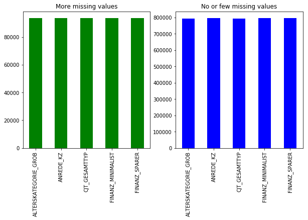

```python
# Compare the distribution of values for at least five columns where there are no
# or few missing values, between the two subsets.
plt.figure(figsize=(10,5))
plt.subplot(1,2,1)
plt.title('More missing values')
azdias_great.iloc[:,:5].count().plot.bar(color='green');
plt.subplot(1,2,2)
plt.title('No or few missing values')
azdias_less.iloc[:,:5].count().plot.bar(color='blue');
```

```python
# Comparing the distibution of five columns randomly
random_column = np.random.choice(azdias.columns,5).tolist()
print(random_column)
```

```
['LP_LEBENSPHASE_GROB', 'KBA05_GBZ', 'WOHNLAGE', 'LP_LEBENSPHASE_GROB', 'W_KEIT_KIND_HH']
```

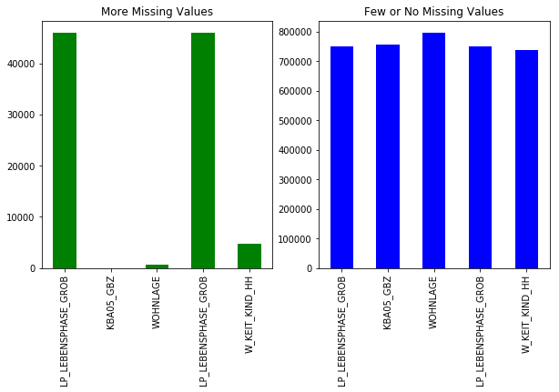

```python
plt.figure(figsize=(10,5))
plt.subplot(1,2,1)
plt.title('More Missing Values')
azdias_great.loc[:,random_column].count().plot.bar(color='green');
plt.subplot(1,2,2)
plt.title('Few or No Missing Values')
azdias_less.loc[:,random_column].count().plot.bar(color='blue');
```

```python
print(azdias_less.shape)
```

```
(797426, 79)
```

#### Discussion

The dataset was divided into two subsets based on the number of missing values in each row more than 20, and less than 20 missing values per row.

### Re-Encode Categorical Variables

```python
# How many features are there of each data type?
features = list(azdias_less.columns)
feat_info_clean = feat_info[feat_info['attribute'].isin(features)]
data_type = feat_info_clean['type'].value_counts()
for i in range(len(data_type)):
    print(' {} {} '.format(data_type[i],data_type.index[i]))

# or
#feat_info.type.value_counts()
```

```
 49 ordinal
 18 categorical
 6 numeric
 6 mixed
```

```python
# Assess categorical variables: which are binary, which are multi-level, and
# which one needs to be re-encoded?
categorical_columns= feat_info.loc[feat_info['type'] == 'categorical', 'attribute'].values
```

```python
binary_column = []
multi_column = []
for i in categorical_columns:
    if azdias_less[i].nunique() > 2:
        multi_column.append(i)
    else:
        binary_column.append(i)
```

```python
for i in binary_column:
    print(azdias_less[i].value_counts())
```

```
2    415781
1    381645
Name: ANREDE_KZ, dtype: int64
0    622259
1    175167
Name: GREEN_AVANTGARDE, dtype: int64
0.0    790714
1.0      6712
Name: SOHO_KZ, dtype: int64
2.0    394161
1.0    366848
Name: VERS_TYP, dtype: int64
W    628987
O    168439
Name: OST_WEST_KZ, dtype: int64
```

```python
# re encode binary columns
azdias_less['ANREDE_KZ'].replace([2,1], [1,0], inplace=True)
azdias_less['VERS_TYP'].replace([2.0,1.0], [1,0], inplace=True)
azdias_less['OST_WEST_KZ'].replace(['W','O'], [1,0], inplace=True)
```

### Drop multi-level Variables

```python
print('Multi-level features: {}'.format(multi_column))
```

```
Multi-level features: ['CJT_GESAMTTYP', 'FINANZTYP', 'GFK_URLAUBERTYP', 'LP_FAMILIE_FEIN', 'LP_FAMILIE_GROB', 'LP_STATUS_FEIN', 'LP_STATUS_GROB', 'NATIONALITAET_KZ', 'SHOPPER_TYP', 'ZABEOTYP', 'GEBAEUDETYP', 'CAMEO_DEUG_2015', 'CAMEO_DEU_2015']
```

```python
# Drop the multi-level features
for feature in multi_column:
    azdias_less = azdias_less.drop(feature, axis=1)
```

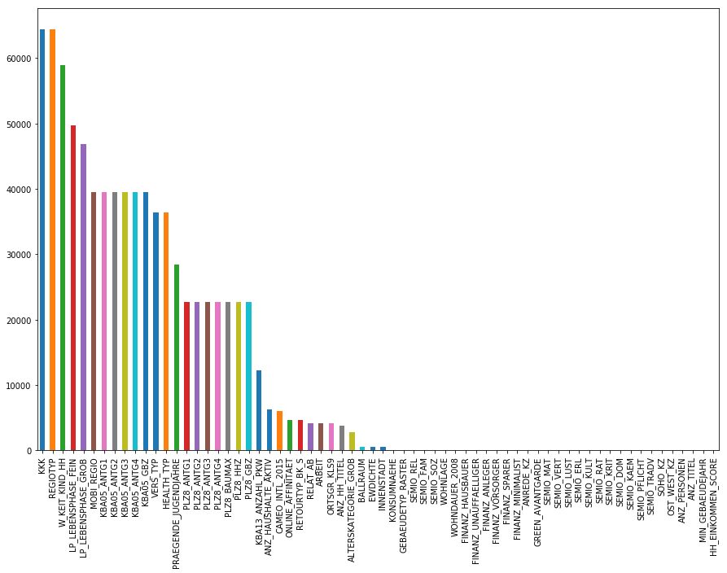

```python
# make sure columns were dropped
azdias_less.isnull().sum().sort_values(ascending=False).plot.bar(figsize=(15,10));
```

```python
print(azdias_less.shape)
```

```
(797426, 66)
```

```python
azdias_clean = azdias_less.copy()
```

```python
print(azdias_clean.shape)
```

```
(797426, 66)
```

#### Discussion

The binary categorical features were encoded with values of 0 and 1. The multi-level categorical features I choose to drop them from the analysis to keep things straightforward.

#### Re-encode and Drop some Mixed-Type Variables

```python
mixed_type = feat_info[feat_info ['type'] =='mixed']
display (mixed_type)
```

|  | attribute | information_level | type | missing_or_unknown |
| --- | --- | --- | --- | --- |
| 15 | LP_LEBENSPHASE_FEIN | person | mixed | [0] |
| 16 | LP_LEBENSPHASE_GROB | person | mixed | [0] |
| 22 | PRAEGENDE_JUGENDJAHRE | person | mixed | [-1,0] |
| 56 | WOHNLAGE | building | mixed | [-1] |
| 59 | CAMEO_INTL_2015 | microcell_rr4 | mixed | [-1,XX] |
| 79 | PLZ8_BAUMAX | macrocell_plz8 | mixed | [-1,0] |

```python
# Investigate "PRAEGENDE_JUGENDJAHRE"
azdias_clean.PRAEGENDE_JUGENDJAHRE.value_counts()
```

```
14.0    182903
8.0     141542
10.0     85767
5.0      84665
3.0      53822
15.0     42521
11.0     35735
9.0      33563
6.0      25651
12.0     24440
1.0      20662
4.0      20450
2.0       7479
13.0      5759
7.0       4009
Name: PRAEGENDE_JUGENDJAHRE, dtype: int64
```

```python
# engineer two new variables of 'PRAEGENDE_JUGENDJAHRE'
azdias_clean['DECADE'] = azdias_clean['PRAEGENDE_JUGENDJAHRE']
azdias_clean['MOVEMENT'] = azdias_clean['PRAEGENDE_JUGENDJAHRE']

decade_dict = {1:1, 2:1, 3:2, 4:2, 5:3, 6:3, 7:3, 8:4, 9:4, 10:5, 11:5, 12:5, 13:5, 14:6, 15:6}
movement_dict = {1:1, 2:0, 3:1, 4:0, 5:1, 6:0, 7:0, 8:1, 9:0, 10:1, 11:0, 12:1, 13:0, 14:1, 15:0}
```

```python
azdias_clean['DECADE'].replace(decade_dict, inplace=True)
azdias_clean['MOVEMENT'].replace(movement_dict, inplace=True)
```

```python
# Investigate 'CAMEO_INTL_2015'
azdias_clean.CAMEO_INTL_2015.value_counts()
```

```
51    133673
41     92309
24     91099
14     62851
43     56653
54     45376
25     39605
22     33137
23     26667
13     26311
45     26126
55     23939
52     20538
31     18979
34     18517
15     16966
44     14817
12     13234
35     10352
32     10346
33      9928
Name: CAMEO_INTL_2015, dtype: int64
```

```python
# engineer two new variables of 'CAMEO_INTL_2015'
azdias_clean['WEALTH'] = azdias_clean['CAMEO_INTL_2015']
azdias_clean['LIFE_STAGE'] = azdias_clean['CAMEO_INTL_2015']


wealth_dict = {11:1, 12:1, 13:1, 14:1, 15:1, 21:2, 22:2, 23:2, 24:2, 25:2,
               31:3, 32:3, 33:3, 34:3, 35:3, 41:4, 42:4, 43:4, 44:4, 45:4,
               51:5, 52:5, 53:5, 54:5, 55:5}

life_stage_dict = {11:1, 12:2, 13:3, 14:4, 15:5, 21:1, 22:2, 23:3, 24:4, 25:5,
                   31:1, 32:2, 33:3, 34:4, 35:5, 41:1, 42:2, 43:3, 44:4, 45:5,
                   51:1, 52:2, 53:3, 54:4, 55:5}
```

```python
azdias_clean['WEALTH'].replace(wealth_dict, inplace=True)
azdias_clean['LIFE_STAGE'].replace(life_stage_dict, inplace=True)
```

```python
mixed_features = feat_info[feat_info['type']== "mixed"]["attribute"]

for i in mixed_features:
    azdias_clean.drop(i, axis=1, inplace=True)
```

#### Discussion

Two mixed-type features were engineered, 'PRAEGENDE_JUGENDJAHRE' and 'CAMEO_INTL_2015' as they combine information on many dimentions. Values of those columns were copied from the initial feature column to the new columns with replacmnet.

The other four mixed-type features were dropped.

### Create a Cleaning Function

I need to create a cleaning function as I will perform the same cleaning steps on the customer demographics data.

```python
def clean_data(df):
    """
    Perform feature trimming, re-encoding, and engineering for demographics
    data

    INPUT: Demographics DataFrame
    OUTPUT: Trimmed and cleaned demographics DataFrame
    """

    for x in range(len(feat_info)):
        missing_or_unknown = feat_info.iloc[x]['missing_or_unknown']
        missing_or_unknown = missing_or_unknown.strip('[')
        missing_or_unknown = missing_or_unknown.strip(']')
        missing_or_unknown = missing_or_unknown.split(sep=',')
        missing_or_unknown = [int(value) if (value!='X' and value!='XX' and value!='') else value for value in missing_or_unknown]
        if missing_or_unknown != ['']:
            clean_df = df.replace({feat_info.iloc[x]['attribute']: missing_or_unknown}, np.nan)

    for i in df.columns:
        clean_df = clean_df.replace({i: ['XX', 'X']}, np.nan)

    # drop the outlier columns from the dataset (Columns with mean > 0.3)
    drop_columns = ['AGER_TYP','GEBURTSJAHR','TITEL_KZ','ALTER_HH','KK_KUNDENTYP','KBA05_BAUMAX']
    clean_df = clean_df.drop(drop_columns, axis=1)


    drop_multi = ['CJT_GESAMTTYP', 'FINANZTYP', 'GFK_URLAUBERTYP', 'LP_FAMILIE_FEIN', 'LP_FAMILIE_GROB', 'LP_STATUS_FEIN', 'LP_STATUS_GROB',
                  'NATIONALITAET_KZ', 'SHOPPER_TYP', 'ZABEOTYP', 'GEBAEUDETYP', 'CAMEO_DEUG_2015', 'CAMEO_DEU_2015']
    clean_df = clean_df.drop(drop_multi, axis=1)


    # select, re-encode, and engineer column values.
    clean_df['ANREDE_KZ'].replace([2,1], [1,0], inplace=True)
    clean_df['VERS_TYP'].replace([2.0,1.0], [1,0], inplace=True)
    clean_df['OST_WEST_KZ'].replace(['W','O'], [1,0], inplace=True)


    #engineer mixed-type features
    clean_df['DECADE'] = clean_df['PRAEGENDE_JUGENDJAHRE']
    clean_df['MOVEMENT'] = clean_df['PRAEGENDE_JUGENDJAHRE']

    decade_dict = {1:1, 2:1, 3:2, 4:2, 5:3, 6:3, 7:3, 8:4, 9:4, 10:5, 11:5, 12:5, 13:5, 14:6, 15:6}
    movement_dict = {1:1, 2:0, 3:1, 4:0, 5:1, 6:0, 7:0, 8:1, 9:0, 10:1, 11:0, 12:1, 13:0, 14:1, 15:0}

    clean_df['DECADE'].replace(decade_dict, inplace=True)
    clean_df['MOVEMENT'].replace(movement_dict, inplace=True)


    #engineer mixed-type features
    clean_df['WEALTH'] = clean_df['CAMEO_INTL_2015']
    clean_df['LIFE_STAGE'] = clean_df['CAMEO_INTL_2015']

    wealth_dict = {11:1, 12:1, 13:1, 14:1, 15:1, 21:2, 22:2, 23:2, 24:2, 25:2,
               31:3, 32:3, 33:3, 34:3, 35:3, 41:4, 42:4, 43:4, 44:4, 45:4,
               51:5, 52:5, 53:5, 54:5, 55:5}

    life_stage_dict = {11:1, 12:2, 13:3, 14:4, 15:5, 21:1, 22:2, 23:3, 24:4, 25:5,
                   31:1, 32:2, 33:3, 34:4, 35:5, 41:1, 42:2, 43:3, 44:4, 45:5,
                   51:1, 52:2, 53:3, 54:4, 55:5}


    clean_df['WEALTH'].replace(wealth_dict, inplace=True)
    clean_df['LIFE_STAGE'].replace(life_stage_dict, inplace=True)


    mixed_features = feat_info[feat_info['type']== "mixed"]["attribute"]
    for i in mixed_features:
        clean_df.drop(i, axis=1, inplace=True)


    # Return the cleaned dataframe.
    return clean_df
```

### Feature Transformation, Apply Feature Scaling

```python
# impute NaNs with the median
imputer = Imputer(strategy='median')
```

```python
# impute NaNs
azdias_clean = pd.DataFrame(imputer.fit_transform(azdias_clean), columns = azdias_clean.columns)
```

```python
# Apply feature scaling to the general population demographics data.
scale = StandardScaler()
azdias_scale = scale.fit_transform(azdias_clean)
azdias_scale_clean = pd.DataFrame(azdias_scale, columns= azdias_clean.columns)
```

```python
print(azdias_clean.shape)
```

```
(797426, 64)
```

### Discussion

All missing values were replaced with the median using the Imputer method. I used median instead of mean because all of the numeric variables are intergers and using the mean would bring float number to the dataset. Features were scaled using the StandardScaler method.

### Perform Dimensionality Reduction

```python
# Apply PCA to the data.
pca = PCA()
pca.fit(azdias_scale_clean)
```

```
PCA(copy=True, iterated_power='auto', n_components=None, random_state=None,
  svd_solver='auto', tol=0.0, whiten=False)
```

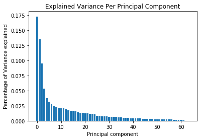

```python
# Investigate the variance accounted for by each principal component.
plt.bar(range(len(pca.explained_variance_ratio_)), pca.explained_variance_ratio_)
plt.title("Explained Variance Per Principal Component")
plt.xlabel("Principal component")
plt.ylabel("Percentage of Variance explained")
plt.show()
```

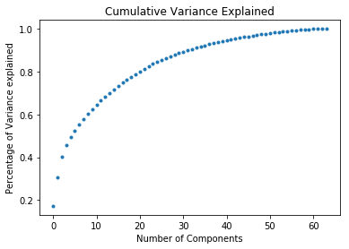

```python
plt.plot(range(len(pca.explained_variance_ratio_)),np.cumsum(pca.explained_variance_ratio_), '.')
plt.title("Cumulative Variance Explained")
plt.xlabel("Number of Components")
plt.ylabel("Percentage of Variance explained")
plt.show()
```

```python
# Re-apply PCA to the data  while selecting for number of components to retain.
pca_35 = PCA(n_components=35)
azdias_pca = pca_35.fit_transform(azdias_scale_clean)
```

### Discussion

I decided to retain 35 principal components for the next step of the analysis, the 35 principal components expalains approximately 90% variance.

### Interpret Principal Components

```python
# Map weights for the first principal component to corresponding feature names
# and then print the linked values, sorted by weight.
# HINT: Try defining a function here or in a new cell that you can reuse in the
# other cells.

#dataframe that captures variability of a given component number
def pca_results(df, pca, comp_n, feat_n):
    pca_component = pd.DataFrame(pca.components_, columns= df.keys()).iloc[comp_n - 1]
    pca_component.sort_values(ascending=False, inplace= True)
    pca_component = pd.concat ([pca_component.head(feat_n), pca_component.tail(feat_n)])

    # plot
    pca_component.plot(kind= 'bar',
                       title= 'Component ' + str(comp_n),
                       figsize= (10, 6))
    plt.show()

    return pca_component
```

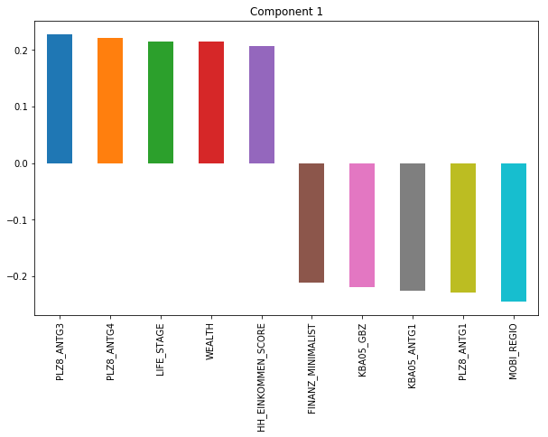

```
PLZ8_ANTG3            0.228094
PLZ8_ANTG4            0.220386
LIFE_STAGE            0.213989
WEALTH                0.213989
HH_EINKOMMEN_SCORE    0.207007
FINANZ_MINIMALIST    -0.210288
KBA05_GBZ            -0.218592
KBA05_ANTG1          -0.224886
PLZ8_ANTG1           -0.228423
MOBI_REGIO           -0.244719
Name: 0, dtype: float64
```

```python
pca_results(azdias_scale_clean,pca, 1, 5)
```

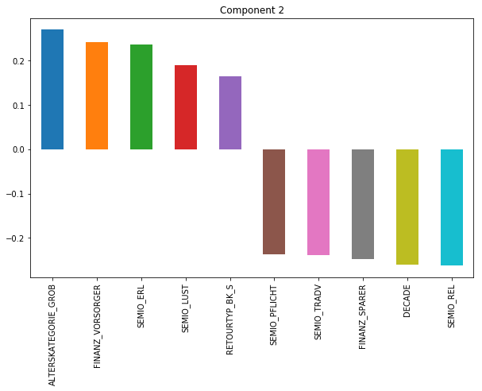

```
ALTERSKATEGORIE_GROB    0.269404
FINANZ_VORSORGER        0.241787
SEMIO_ERL               0.235298
SEMIO_LUST              0.189198
RETOURTYP_BK_S          0.164694
SEMIO_PFLICHT          -0.236286
SEMIO_TRADV            -0.238429
FINANZ_SPARER          -0.247020
DECADE                 -0.259668
SEMIO_REL              -0.261907
Name: 1, dtype: float64
```

```python
# Map weights for the second principal component to corresponding feature names
# and then print the linked values, sorted by weight.

pca_results(azdias_scale_clean,pca, 2, 5)
```

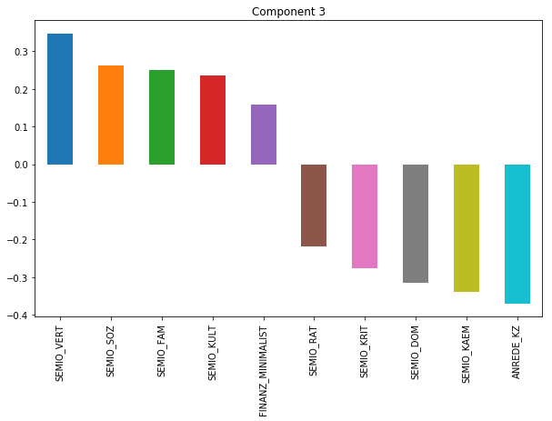

```
SEMIO_VERT           0.345918
SEMIO_SOZ            0.262287
SEMIO_FAM            0.250253
SEMIO_KULT           0.235816
FINANZ_MINIMALIST    0.157644
SEMIO_RAT           -0.217538
SEMIO_KRIT          -0.276677
SEMIO_DOM           -0.315024
SEMIO_KAEM          -0.338126
ANREDE_KZ           -0.369039
Name: 2, dtype: float64
```

```python
# Map weights for the third principal component to corresponding feature names
# and then print the linked values, sorted by weight.

pca_results(azdias_scale_clean,pca, 3, 5)
```

### Discussion

Interpretation of first three components:

**First Component:**

  It appears that the first component is related to number of 6-10, 10+, and 1-2 family houses in the PLZ8 region and their movement patterns and their wealth / life stage typology.

**Second Component:**

- Has a positive corelation with:
  - 'ALTERSKATEGORIE_GROB' (Estimated age based on given name analysis)
  - 'FINANZ_VORSORGER' (Financial typology, be prepared)
  - 'SEMIO_ERL' (Personality typology, event-oriented)
  - 'SEMIO_LUST' (Personality typology, sensual-minded)
  - 'RETOURTYP_BK_S' (Return type, "higher is Low-Returner")
- Has a negative correlation with:
  - 'SEMIO_PFLICHT' (Personality typology, dutiful)
  - 'SEMIO_TRADV' (Personality typology,tradional-minded)
  - 'FINANZ_SPARER' (Financial typology, money-saver)
    - 'DECADE'
  - 'SEMIO_REL' (Personality typology, religious)

  It appears that the second component is related to age, personality typology, and financial savings.

**Third Component:**

- Has a positive corelation with:
  - 'SEMIO_VERT' (Personality typology, dreamful)
  - 'SEMIO_SOZ' (Personality typology, socially-minded)
  - 'SEMIO_FAM' (Personality typology, family-minded)
  - 'SEMIO_KULT' (Personality typology, cultural-minded)
  - 'FINANZ_MINIMALIST' (Financial typology, low financial interest)
- Has a negative corelation with:
  - 'SEMIO_RAT'(Personality typology, rational)
  - 'SEMIO_KRIT' (Personality typology, critical-minded)
  - 'SEMIO_DOM' (Personality typology, dominant-minded)
  - 'SEMIO_KAEM' (Personality typology, combative attitude)
  - 'ANREDE_KZ' ("Gender" 1: male, 2: female)

  It appears that the third component is related to personality typology and gender. It separates family-minded and social female vs dominant-minded and combative male.

## Clustering

```python
def get_kmeans_score(data, center):
    '''
    returns the kmeans score regarding SSE for points to centers
    INPUT:
        data - the dataset you want to fit kmeans to
        center - the number of centers you want (the k value)
    OUTPUT:
        score - the SSE score for the kmeans model fit to the data
    '''
    #instantiate kmeans
    kmeans = KMeans(n_clusters=center)

    # Then fit the model to your data using the fit method
    model = kmeans.fit(data)

    # Obtain a score related to the model fit
    score = np.abs(model.score(data)) #absolute value taken

    return score
```

```python
# Over a number of different cluster counts...
# run k-means clustering on the data and...
# compute the average within-cluster distances.

scores = []
centers = list(range(1,20))

for center in centers:
    scores.append(get_kmeans_score(azdias_pca, center))

# Investigate the change in within-cluster distance across number of clusters.
# HINT: Use matplotlib's plot function to visualize this relationship.
plt.plot(centers, scores, linestyle='--', marker='o', color='b');
plt.xlabel('K');
plt.ylabel('SSE');
plt.title('SSE vs. K')
```

[output not shown]

```python
# Re-fit the k-means model with the selected number of clusters and obtain
# cluster predictions for the general population demographics data.

kmeans = KMeans(n_clusters=10)
model = kmeans.fit(azdias_pca)
azdias_predict = model.predict(azdias_pca)
```

### Discussion

After investigating the change in within-cluster distance across number of clusters, I decided to choose 10 clusters as it seems to be the most appropriate number of clusters.

### Apply All Steps to the Customer Data

```python
# Load in the customer demographics data.
customers = pd.read_csv('../../data/Term2/capstone/arvato_data/Udacity_CUSTOMERS_052018.csv', sep=';')
```

```python
customers.head(5)
```

|  | AGER_TYP | ALTERSKATEGORIE_GROB | ANREDE_KZ | CJT_GESAMTTYP | FINANZ_MINIMALIST | FINANZ_SPARER | FINANZ_VORSORGER | FINANZ_ANLEGER | FINANZ_UNAUFFAELLIGER | FINANZ_HAUSBAUER | ... | PLZ8_ANTG1 | PLZ8_ANTG2 | PLZ8_ANTG3 | PLZ8_ANTG4 | PLZ8_BAUMAX | PLZ8_HHZ | PLZ8_GBZ | ARBEIT | ORTSGR_KLS9 | RELAT_AB |
| --- | --- | --- | --- | --- | --- | --- | --- | --- | --- | --- | --- | --- | --- | --- | --- | --- | --- | --- | --- | --- | --- |
| 0 | 2 | 4 | 1 | 5.0 | 5 | 1 | 5 | 1 | 2 | 2 | ... | 3.0 | 3.0 | 1.0 | 0.0 | 1.0 | 5.0 | 5.0 | 1.0 | 2.0 | 1.0 |
| 1 | -1 | 4 | 1 | NaN | 5 | 1 | 5 | 1 | 3 | 2 | ... | NaN | NaN | NaN | NaN | NaN | NaN | NaN | NaN | NaN | NaN |
| 2 | -1 | 4 | 2 | 2.0 | 5 | 1 | 5 | 1 | 4 | 4 | ... | 2.0 | 3.0 | 3.0 | 1.0 | 3.0 | 3.0 | 2.0 | 3.0 | 5.0 | 3.0 |
| 3 | 1 | 4 | 1 | 2.0 | 5 | 1 | 5 | 2 | 1 | 2 | ... | 3.0 | 2.0 | 1.0 | 0.0 | 1.0 | 3.0 | 4.0 | 1.0 | 3.0 | 1.0 |
| 4 | -1 | 3 | 1 | 6.0 | 3 | 1 | 4 | 4 | 5 | 2 | ... | 2.0 | 4.0 | 2.0 | 1.0 | 2.0 | 3.0 | 3.0 | 3.0 | 5.0 | 1.0 |

5 rows × 85 columns

```python
# Apply preprocessing, feature transformation, and clustering from the general
# demographics onto the customer data, obtaining cluster predictions for the
# customer demographics data.

customers = clean_data(customers)
```

```python
customers.head(5)
```

|  | ALTERSKATEGORIE_GROB | ANREDE_KZ | FINANZ_MINIMALIST | FINANZ_SPARER | FINANZ_VORSORGER | FINANZ_ANLEGER | FINANZ_UNAUFFAELLIGER | FINANZ_HAUSBAUER | GREEN_AVANTGARDE | HEALTH_TYP | ... | PLZ8_ANTG4 | PLZ8_HHZ | PLZ8_GBZ | ARBEIT | ORTSGR_KLS9 | RELAT_AB | DECADE | MOVEMENT | WEALTH | LIFE_STAGE |
| --- | --- | --- | --- | --- | --- | --- | --- | --- | --- | --- | --- | --- | --- | --- | --- | --- | --- | --- | --- | --- | --- |
| 0 | 4 | 0 | 5 | 1 | 5 | 1 | 2 | 2 | 1 | 1 | ... | 0.0 | 5.0 | 5.0 | 1.0 | 2.0 | 1.0 | 2 | 0 | 13 | 13 |
| 1 | 4 | 0 | 5 | 1 | 5 | 1 | 3 | 2 | 0 | 1 | ... | NaN | NaN | NaN | NaN | NaN | NaN | 0 | 0 | NaN | NaN |
| 2 | 4 | 1 | 5 | 1 | 5 | 1 | 4 | 4 | 1 | 2 | ... | 1.0 | 3.0 | 2.0 | 3.0 | 5.0 | 3.0 | 2 | 0 | 34 | 34 |
| 3 | 4 | 0 | 5 | 1 | 5 | 2 | 1 | 2 | 0 | 2 | ... | 0.0 | 3.0 | 4.0 | 1.0 | 3.0 | 1.0 | 1 | 1 | 24 | 24 |
| 4 | 3 | 0 | 3 | 1 | 4 | 4 | 5 | 2 | 0 | 3 | ... | 1.0 | 3.0 | 3.0 | 3.0 | 5.0 | 1.0 | 4 | 1 | 41 | 41 |

5 rows × 64 columns

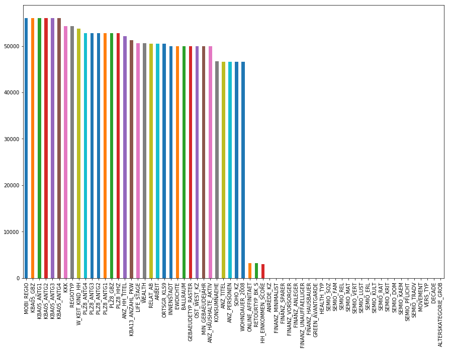

```python
customers.isnull().sum().sort_values(ascending=False).plot.bar(figsize=(15,10));
```

```python
# impute NaNs
customers_imputed = pd.DataFrame(imputer.fit_transform(customers))
customers_imputed.columns = customers.columns
customers_imputed.index = customers.index
```

[figure not shown]

```python
customers_imputed.isnull().sum().sort_values(ascending=False).plot.bar(figsize=(15,10));
```

```python
# apply scaler
customers_scaled = pd.DataFrame(scale.transform(customers_imputed), columns = customers_imputed.columns)
```

```python
# apply the fitted pca to the customer data
customers_pca = pca_35.transform(customers_scaled)
customers_pca.shape
```

```
(191652, 35)
```

```python
# apply kmeans to the customer data
customers_predict = model.predict(customers_pca)
```

```python
customers.shape
```

```
(191652, 64)
```

```python
azdias_clean.shape
```

```
(797426, 64)
```

### Compare Customer Data to Demographics Data

```python
# Compare the proportion of data in each cluster for the customer data to the
# proportion of data in each cluster for the general population.

cluster_general = {x:sum(azdias_predict == x)/len(azdias_predict) for x in range(10)}
cluster_customer = {x:sum(customers_predict == x)/len(customers_predict) for x in range(10)}
```

```python
df_cluster = pd.DataFrame({'Cluster': list(cluster_general.keys()),
                          'General': list(cluster_general.values()),
                          'Customer': list(cluster_customer.values())})
```

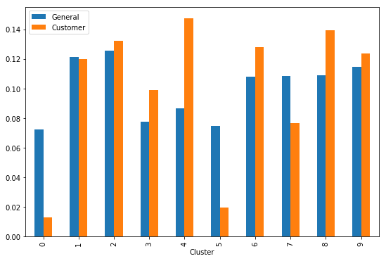

```python
df_cluster.plot(x='Cluster', y = ['General', 'Customer'], kind='bar', figsize=(9,6));
```

```python
# What kinds of people are part of a cluster that is overrepresented in the
# customer data compared to the general population?

centroid_4 = scale.inverse_transform(pca_35.inverse_transform(model.cluster_centers_[4]))
overrepresented = pd.DataFrame(data = centroid_4, index = customers.columns)
overrepresented
```

|  | 0 |
| --- | --- |
| ALTERSKATEGORIE_GROB | 3.918866 |
| ANREDE_KZ | -0.279462 |
| FINANZ_MINIMALIST | 5.277851 |
| FINANZ_SPARER | 0.702574 |
| FINANZ_VORSORGER | 4.957046 |
| FINANZ_ANLEGER | 0.369335 |
| FINANZ_UNAUFFAELLIGER | 1.056328 |
| FINANZ_HAUSBAUER | 1.900319 |
| GREEN_AVANTGARDE | 0.801968 |
| HEALTH_TYP | 2.725777 |
| RETOURTYP_BK_S | 4.368717 |
| SEMIO_SOZ | 6.045935 |
| SEMIO_FAM | 4.744469 |
| SEMIO_REL | 3.156570 |
| SEMIO_MAT | 3.998062 |
| SEMIO_VERT | 8.068162 |
| SEMIO_LUST | 5.574456 |
| SEMIO_ERL | 3.804922 |
| SEMIO_KULT | 5.931956 |
| SEMIO_RAT | 2.259441 |
| SEMIO_KRIT | 1.484938 |
| SEMIO_DOM | 2.193372 |
| SEMIO_KAEM | 1.097195 |
| SEMIO_PFLICHT | 2.584874 |
| SEMIO_TRADV | 3.301166 |
| SOHO_KZ | 0.006143 |
| VERS_TYP | 0.789475 |
| ANZ_PERSONEN | 2.520191 |
| ANZ_TITEL | 0.030765 |
| HH_EINKOMMEN_SCORE | 2.693967 |
| ... | ... |
| KONSUMNAEHE | 3.367271 |
| MIN_GEBAEUDEJAHR | 1993.372980 |
| OST_WEST_KZ | 0.865321 |
| KBA05_ANTG1 | 2.810361 |
| KBA05_ANTG2 | 1.000859 |
| KBA05_ANTG3 | 0.117790 |
| KBA05_ANTG4 | 0.125688 |
| KBA05_GBZ | 3.911087 |
| BALLRAUM | 3.905217 |
| EWDICHTE | 4.005571 |
| INNENSTADT | 4.471805 |
| GEBAEUDETYP_RASTER | 3.986367 |
| KKK | 1.993465 |
| MOBI_REGIO | 4.018462 |
| ONLINE_AFFINITAET | 3.654014 |
| REGIOTYP | 2.978615 |
| KBA13_ANZAHL_PKW | 726.370393 |
| PLZ8_ANTG1 | 2.552852 |
| PLZ8_ANTG2 | 2.535845 |
| PLZ8_ANTG3 | 1.417071 |
| PLZ8_ANTG4 | 0.641391 |
| PLZ8_HHZ | 3.914040 |
| PLZ8_GBZ | 3.722005 |
| ARBEIT | 2.936711 |
| ORTSGR_KLS9 | 5.351543 |
| RELAT_AB | 2.968939 |
| DECADE | 3.648615 |
| MOVEMENT | 0.458984 |
| WEALTH | 26.719773 |
| LIFE_STAGE | 26.719773 |

64 rows × 1 columns

```python
# What kinds of people are part of a cluster that is underrepresented in the
# customer data compared to the general population?

centroid_0 = scale.inverse_transform(pca_35.inverse_transform(model.cluster_centers_[0]))
underrepresented = pd.DataFrame(data = centroid_0, index = customers.columns)
underrepresented
```

|  | 0 |
| --- | --- |
| ALTERSKATEGORIE_GROB | 2.058328 |
| ANREDE_KZ | 0.772667 |
| FINANZ_MINIMALIST | 2.798499 |
| FINANZ_SPARER | 3.409920 |
| FINANZ_VORSORGER | 3.195187 |
| FINANZ_ANLEGER | 4.497669 |
| FINANZ_UNAUFFAELLIGER | 3.972999 |
| FINANZ_HAUSBAUER | 3.182651 |
| GREEN_AVANTGARDE | -0.403176 |
| HEALTH_TYP | 0.331848 |
| RETOURTYP_BK_S | 3.043083 |
| SEMIO_SOZ | 2.103358 |
| SEMIO_FAM | 4.676392 |
| SEMIO_REL | 5.420237 |
| SEMIO_MAT | 3.958608 |
| SEMIO_VERT | 1.531906 |
| SEMIO_LUST | 4.231922 |
| SEMIO_ERL | 4.480468 |
| SEMIO_KULT | 2.645236 |
| SEMIO_RAT | 4.433376 |
| SEMIO_KRIT | 6.784243 |
| SEMIO_DOM | 5.903743 |
| SEMIO_KAEM | 6.328242 |
| SEMIO_PFLICHT | 4.908127 |
| SEMIO_TRADV | 3.137175 |
| SOHO_KZ | -0.050804 |
| VERS_TYP | -0.408648 |
| ANZ_PERSONEN | 2.021962 |
| ANZ_TITEL | -0.045257 |
| HH_EINKOMMEN_SCORE | 3.768252 |
| ... | ... |
| KONSUMNAEHE | 3.369468 |
| MIN_GEBAEUDEJAHR | 1994.249257 |
| OST_WEST_KZ | 0.863837 |
| KBA05_ANTG1 | 1.495515 |
| KBA05_ANTG2 | 0.923264 |
| KBA05_ANTG3 | 0.192921 |
| KBA05_ANTG4 | 0.261624 |
| KBA05_GBZ | 3.497099 |
| BALLRAUM | 5.813828 |
| EWDICHTE | 2.981660 |
| INNENSTADT | 5.709468 |
| GEBAEUDETYP_RASTER | 3.999069 |
| KKK | 2.545663 |
| MOBI_REGIO | 3.435346 |
| ONLINE_AFFINITAET | 2.681970 |
| REGIOTYP | 4.697555 |
| KBA13_ANZAHL_PKW | 636.265413 |
| PLZ8_ANTG1 | 2.776279 |
| PLZ8_ANTG2 | 2.787616 |
| PLZ8_ANTG3 | 1.015149 |
| PLZ8_ANTG4 | 0.150682 |
| PLZ8_HHZ | 3.106569 |
| PLZ8_GBZ | 3.806063 |
| ARBEIT | 2.647551 |
| ORTSGR_KLS9 | 3.786366 |
| RELAT_AB | 2.417071 |
| DECADE | 1.825878 |
| MOVEMENT | 0.792425 |
| WEALTH | 33.678713 |
| LIFE_STAGE | 33.678713 |

64 rows × 1 columns

### Discussion

After comparing the population clusters that are popular and unpopular with the mail order company we can conclude the following:

- **Cluster 4 is the most overrepresented cluster in customers data compared to general data followed by cluster 8, 6, 3, 9, and 2**

  By looking at the plot above, we can see that the data points that are defined by clusters 4, 8, 6, 3, 9, and 2 are highly likely customer segments as the larger praportion of customer data is present at these points
- **Cluster 0 is the most underrepresented cluster in the customers data compared to the general population data followed by cluster 5, 7, and 1**

  By looking at the plot above, we can see the data points that are defined by clusters 0, 5, 7, and 1 are less likely to be turned into customers as these clusters are general population data dominated.

### Conclusion

Since there is a small difference between nearly half of the predictions demographics of the general populations and the customer data, we can recommend the Aviato company to use these information to select part of the general population for their business. keeping in mind that we have removed some columns that may contain some information that could lead to different findings.